# Nursing Home Utilization-Tree, Bagging, Random Forest

Silvia

2023-01-19

## Tree, Bagging, Random Forest

Some pre-processing steps on the dataset:

```r
#import and rename the dataset
datafile <- read.csv("WiscNursingHome.csv")
#Eliminate the missing values
datafile <- na.omit(datafile)
#Factorization of the categorical variables
datafile$ORGSTR <- as.factor(datafile$ORGSTR)
datafile$MSA <- as.factor(datafile$MSA)
datafile$SELFFUNDINS <- as.factor(datafile$SELFFUNDINS)
datafile$MCERT <- as.factor(datafile$MCERT)
```

Because of the fact that our data are referred to two different years, and we can’t consider the values independent from one year to another, we use the data about the 2000 as our training set, and the 2001 as the test set.

```r
data_2000 <- datafile[datafile$CRYEAR == 2000, ] #train
data_2001 <- datafile[datafile$CRYEAR == 2001, ] #test
```

Some libraries:

```r
library("rpart") #tree
library("rpart.plot") #tree plot
library("Metrics")  # rmse
library("ipred") #Bagging, first method
library("caret") #Bagging, second method
library("randomForest") # Random Forest
```

*Some considerations about the model evaluations* For each model proposed, it is reported the RMSE (Root Mean Squared Error) as a measure of the accuracy of the model. For the RMSE, the lower the better(it is the standard deviation between the predicted values and the real values from the test dataset)

##Final results

Best result with Trees(cp=0): RMSE = 13.42 Best result with Bagging(caret package): RMSE = 14.47 Random Forest: RMSE = 13.80

Best result: Regression Tree (ha senso?)

### Regression trees

1)Maximal complexity (cp=0)

```r
set.seed(123)
fit_tree <- rpart(TPY ~NUMBED + SQRFOOT + MSA + SELFFUNDINS + MCERT + ORGSTR, data=data_2000, method = "anova", control = rpart.control(cp = 0))
printcp(fit_tree) #cp table
```

```
##
## Regression tree:
## rpart(formula = TPY ~ NUMBED + SQRFOOT + MSA + SELFFUNDINS +
##     MCERT + ORGSTR, data = data_2000, method = "anova", control = rpart.control(cp = 0))
##
## Variables actually used in tree construction:
## [1] MCERT   MSA     NUMBED  ORGSTR  SQRFOOT
##
## Root node error: 758006/357 = 2123.3
##
## n= 357
##
##            CP nsplit rel error   xerror     xstd
## 1  6.1243e-01      0  1.000000 1.006003 0.116752
## 2  1.6252e-01      1  0.387568 0.410768 0.046328
```

[output cut: 27 more lines]

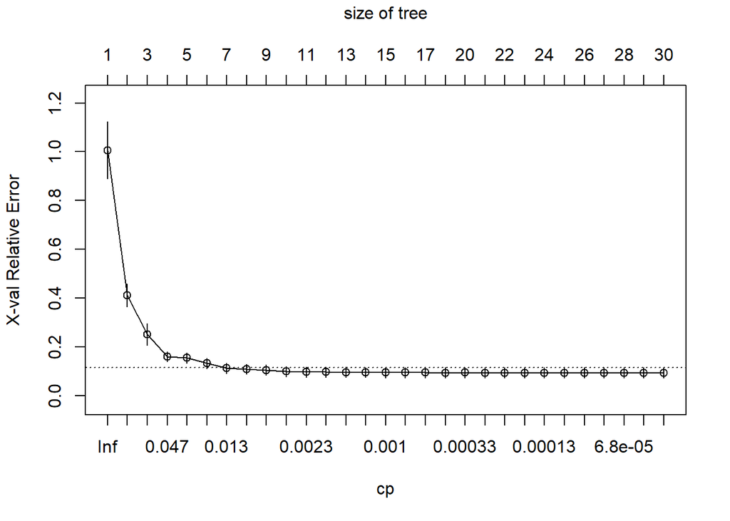

```r
plotcp(fit_tree) #plot cp values, error, splits
```

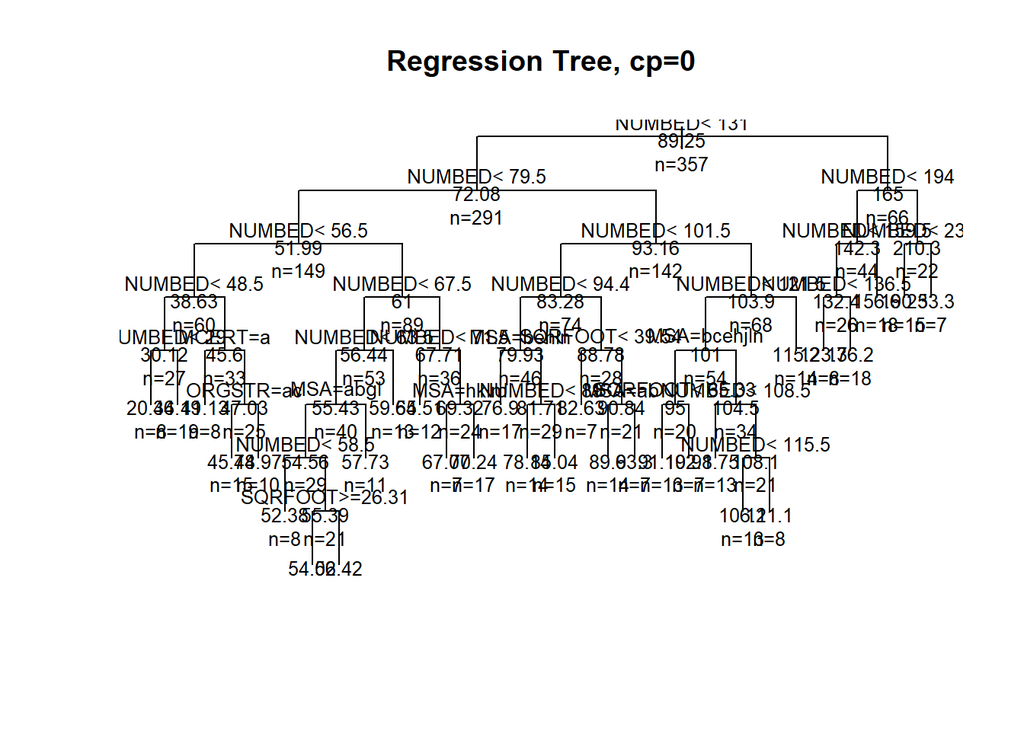

```r
plot(fit_tree, uniform = TRUE, main = "Regression Tree, cp=0") #Tree plot
text(fit_tree, use.n = TRUE, all = TRUE, cex = .8)
```

```r
pred <- predict(fit_tree, newdata = data_2001)
rmse(data_2001$TPY, pred)
```

```
## [1] 13.42062
```

2)Automatic choice of the cp

```r
set.seed(123)
fit_tree <- rpart(TPY ~NUMBED + SQRFOOT + MSA + SELFFUNDINS + MCERT + ORGSTR, data=data_2000, method = "anova")
printcp(fit_tree) #cp table
```

```
##
## Regression tree:
## rpart(formula = TPY ~ NUMBED + SQRFOOT + MSA + SELFFUNDINS +
##     MCERT + ORGSTR, data = data_2000, method = "anova")
##
## Variables actually used in tree construction:
## [1] NUMBED
##
## Root node error: 758006/357 = 2123.3
##
## n= 357
##
##         CP nsplit rel error  xerror     xstd
## 1 0.612432      0  1.000000 1.00600 0.116752
## 2 0.162520      1  0.387568 0.41077 0.046328
## 3 0.089618      2  0.225048 0.25077 0.045563
## 4 0.025019      3  0.135430 0.15931 0.020932
## 5 0.023651      4  0.110410 0.15417 0.021138
## 6 0.019879      5  0.086759 0.13201 0.021132
## 7 0.010000      6  0.066879 0.11662 0.020930
```

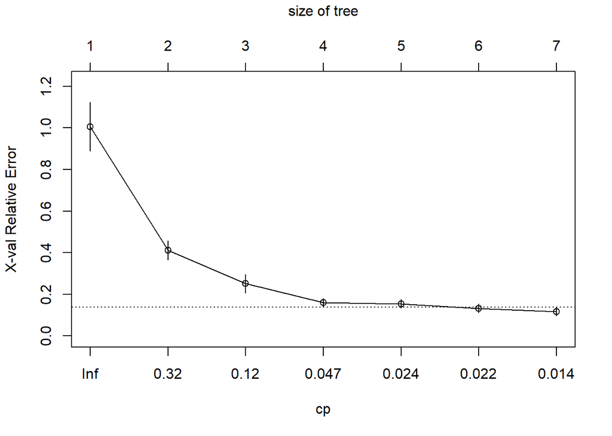

```r
plotcp(fit_tree) #plot cp values, error, splits
```

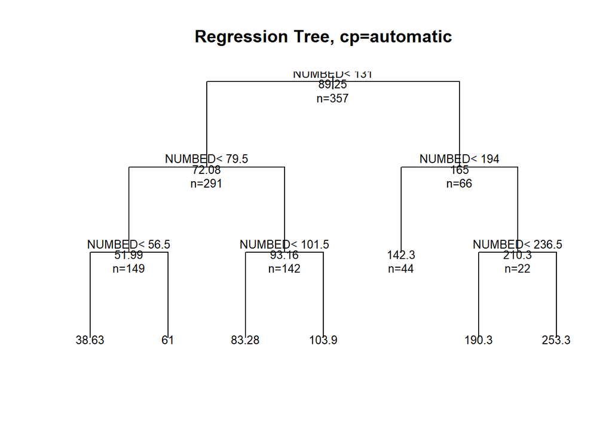

```r
plot(fit_tree, uniform = TRUE, main = "Regression Tree, cp=automatic") #Tree plot
text(fit_tree, use.n = TRUE, all = TRUE, cex = .8)
```

```r
pred <- predict(fit_tree, newdata = data_2001)
rmse(data_2001$TPY, pred)
```

```
## [1] 15.68372
```

The automatic choice of the cp value is cp=0.01. In this case the model is a tree with 7 terminal nodes and it is used only 1 variable, NUMBED.

3)Manual set of the cp=0.0017

```r
set.seed(123)
fit_tree <- rpart(TPY ~NUMBED + SQRFOOT + MSA + SELFFUNDINS + MCERT + ORGSTR, data=data_2000, method = "anova", control = rpart.control(cp = 0.0017))
printcp(fit_tree) #cp table
```

```
##
## Regression tree:
## rpart(formula = TPY ~ NUMBED + SQRFOOT + MSA + SELFFUNDINS +
##     MCERT + ORGSTR, data = data_2000, method = "anova", control = rpart.control(cp = 0.0017))
##
## Variables actually used in tree construction:
## [1] NUMBED
##
## Root node error: 758006/357 = 2123.3
##
## n= 357
##
##           CP nsplit rel error   xerror     xstd
## 1  0.6124321      0  1.000000 1.006003 0.116752
## 2  0.1625204      1  0.387568 0.410768 0.046328
## 3  0.0896177      2  0.225048 0.250767 0.045563
## 4  0.0250194      3  0.135430 0.159306 0.020932
## 5  0.0236515      4  0.110410 0.154173 0.021138
## 6  0.0198795      5  0.086759 0.132013 0.021132
## 7  0.0082618      6  0.066879 0.112200 0.020859
## 8  0.0046957      7  0.058618 0.108175 0.020921
## 9  0.0035944      8  0.053922 0.104297 0.020927
## 10 0.0029526      9  0.050328 0.098734 0.020963
## 11 0.0017986     10  0.047375 0.096398 0.020873
## 12 0.0017000     11  0.045576 0.095711 0.020872
```

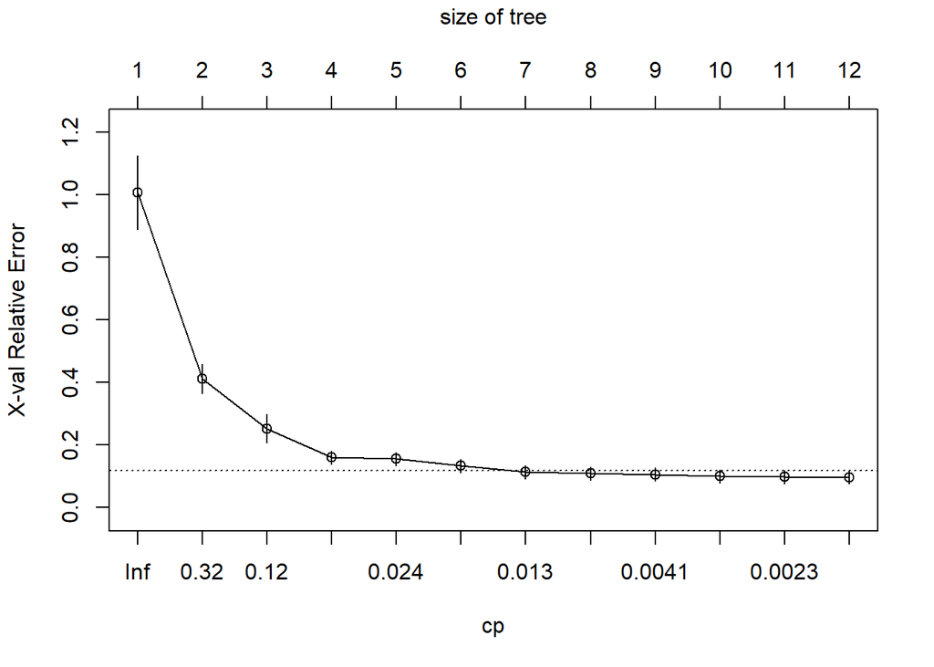

```r
plotcp(fit_tree) #plot cp values, error, splits
```

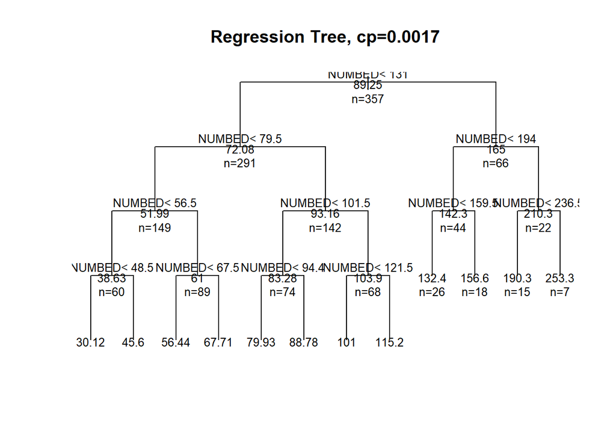

```r
plot(fit_tree, uniform = TRUE, main = "Regression Tree, cp=0.0017") #Tree plot
text(fit_tree, use.n = TRUE, all = TRUE, cex = .8)
```

```r
pred <- predict(fit_tree, newdata = data_2001)
rmse(data_2001$TPY, pred)
```

```
## [1] 14.02511
```

With a cp=0.0017 (this additional trial is to see the effect of another level of complexity) we have 12 terminal nodes and it uses only 1 variable, NUMBED.

### Bagging

1)ipred package

First, let find the best number of trees to use

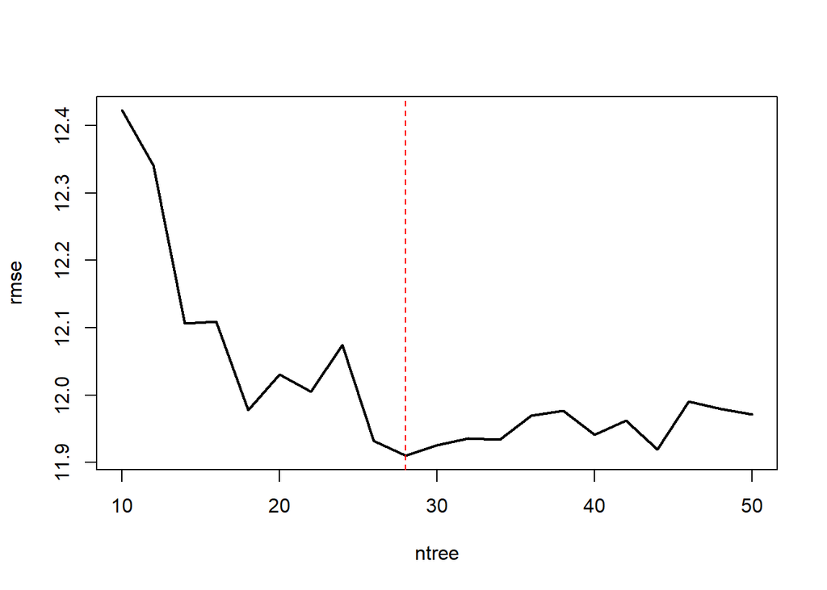

```r
ntree <- seq(10, 50, 2)
rmse <- vector(mode = "numeric", length = length(ntree))
for (i in seq_along(ntree)) {
  # reproducibility
  set.seed(123)

  # perform bagged model
  fit_bag <- bagging(TPY ~ NUMBED + SQRFOOT + MSA + SELFFUNDINS + MCERT + ORGSTR, data=data_2000, coob = TRUE, nbagg   = ntree[i])
  # get OOB error
  rmse[i] <-fit_bag$err
}

plot(ntree, rmse, type = 'l', lwd = 2)
abline(v = 28, col = "red", lty = "dashed")
```

Bagging with 28 trees:

```r
set.seed(123)

# train
fit_bag28 <- bagging(TPY ~ NUMBED + SQRFOOT + MSA + SELFFUNDINS + MCERT + ORGSTR, nbagg=28, data=data_2000, coob = TRUE)

fit_bag28
```

```
##
## Bagging regression trees with 28 bootstrap replications
##
## Call: bagging.data.frame(formula = TPY ~ NUMBED + SQRFOOT + MSA + SELFFUNDINS +
##     MCERT + ORGSTR, data = data_2000, nbagg = 28, coob = TRUE)
##
## Out-of-bag estimate of root mean squared error:  11.9103
```

```r
pred <- predict(fit_bag28, data_2001)
rmse(pred, data_2001$TPY)
```

```
## [1] 14.54251
```

2. caret package

```r
# Specify 10-fold cross validation
set.seed(123)
ctrl <- trainControl(method = "cv",  number = 10)

# CV bagged model
fit_bag <- train(TPY ~ NUMBED + SQRFOOT + MSA + SELFFUNDINS + MCERT + ORGSTR, data = data_2000, method = "treebag", trControl = ctrl, importance = TRUE)

fit_bag
```

```
## Bagged CART
##
## 357 samples
##   6 predictor
##
## No pre-processing
## Resampling: Cross-Validated (10 fold)
## Summary of sample sizes: 321, 321, 321, 321, 321, 321, ...
## Resampling results:
##
##   RMSE      Rsquared   MAE
##   12.04275  0.9398946  7.492868
```

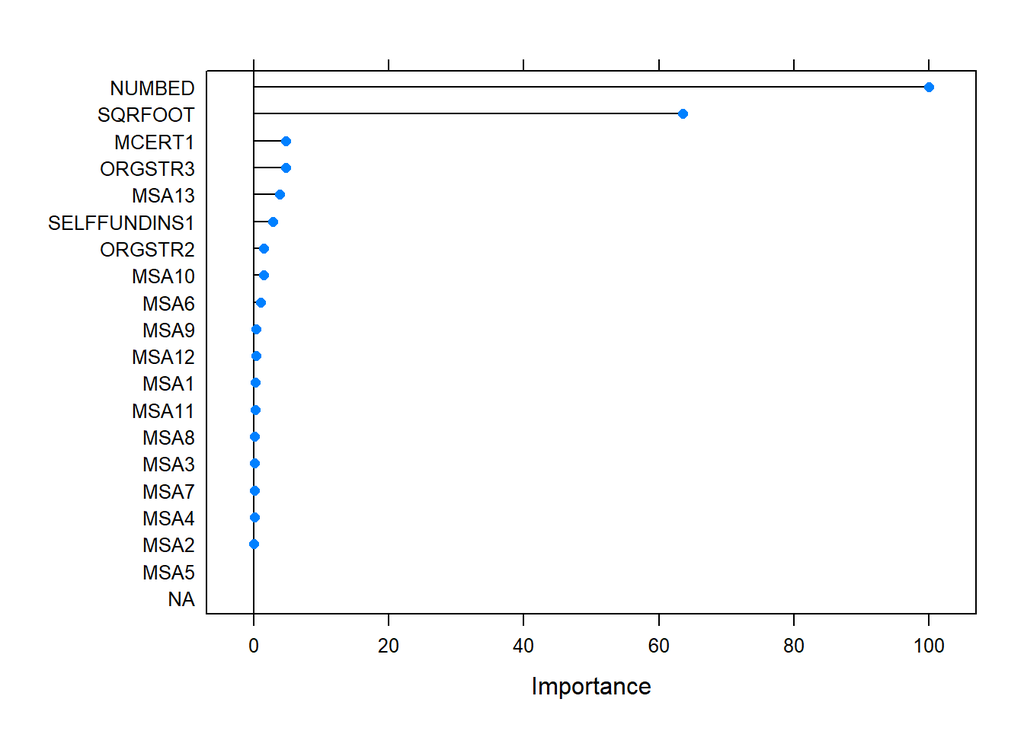

```r
plot(varImp(fit_bag), 20)
```

```r
pred <- predict(fit_bag, data_2001)
rmse(pred, data_2001$TPY)
```

```
## [1] 14.47064
```

### Random Forest

Random forest with 500 trees(default, but good)

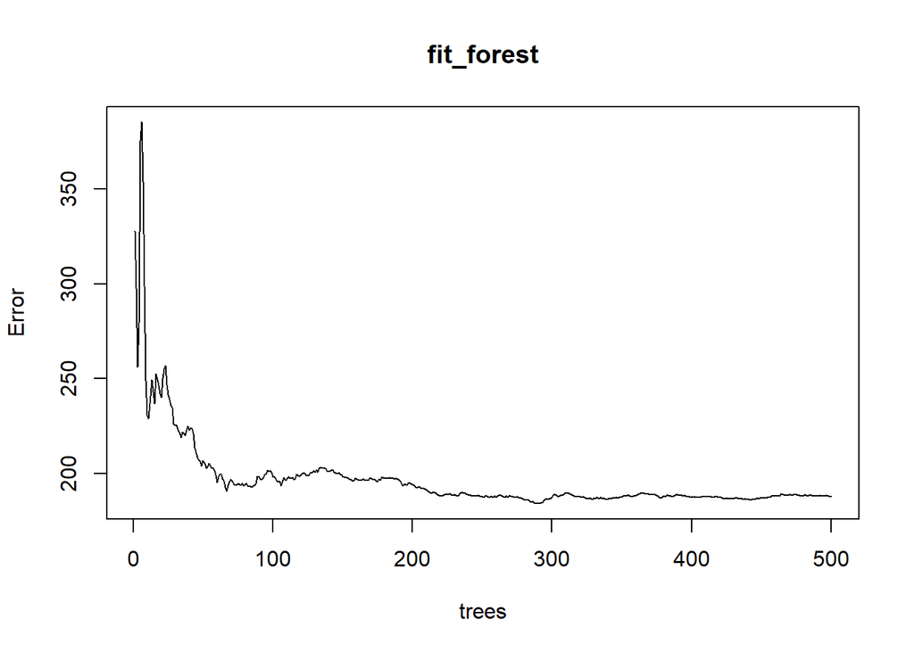

```r
set.seed(123)
fit_forest <- randomForest(TPY ~ NUMBED + SQRFOOT + MSA + SELFFUNDINS + MCERT + ORGSTR, data = data_2000, proximity=TRUE)
plot(fit_forest)
```

```r
pred <- predict(fit_forest, data_2001)
rmse(pred, data_2001$TPY)
```

```
## [1] 13.79905
```